# Acidentes fatais envolvendo ciclistas no município de São Paulo

Guilherme J. S. Militão

23-02-2022

## Justificativa

O presente relatório é o trabalho final do curso de Relatórios Reprodutíveis com R, do IME-USP, em 2022.

## Objetivos

O objetvo do relatório é comparar os dados sobre acidentes fatais envolvendo ciclistas no município de São Paulo/BR entre os períodos de 1 ano antes e depois de uma data determinada como parâmetro. Como exemplo, foi considerada a data de início da pandemia de COVID-19.

[figure not shown]

## Fontes

A data considerada como início da pandemia de COVID-19 é 11/03/2020, seguindo o que foi estabelecido pela Organização Mundial da Saúde[^1]. A data de referência pode ser alterada a depender do objetivo da análise.

As bases de dados utilizadas na análise são provenientes do Governo do Estado de São Paulo e estão disponíveis no portal http://www.respeitoavida.sp.gov.br/relatorios/.

Os links para donwload estão disponíveis aqui:

- [Óbitos](http://painelderesultados.infosiga.sp.gov.br/bases/obitos_publico.csv)
- [Acidentes fatais](http://painelderesultados.infosiga.sp.gov.br/bases/acidentes_fatais.xlsx)

## Resumo dos números

No período de 1 ano antes de 11/03/2020, ocorreram 27 acidentes com mortes de ciclistas, com uma média de 2.2 acidentes por mês.

Já no período de 1 ano depois de 11/03/2020, ocorreram 37 acidentes com mortes de ciclistas, com uma média de 3.1 acidentes por mês, um aumento de 37% em relação ao período anterior.

| Período em relação à referência | Quantidade de acidentes |
| --- | --- |
| Antes | 27 |
| Depois | 37 |

## Gráficos

### Número de acidentes com óbitos de ciclistas - 1 ano antes e depois de 11/03/2020 (data de referência)

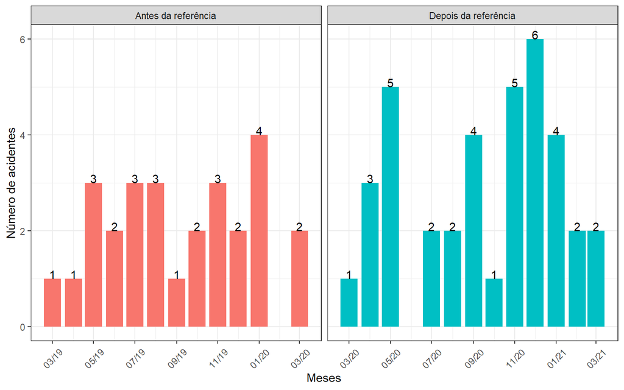

[figure not shown]

[^1]: Mais informações em https://www.paho.org/pt/covid19/historico-da-pandemia-covid-19